Näringslivet i Dalarna

# Näringslivet i Dalarna

Rapporten är skapad av Samhällsanalys, Region Dalarna  
Senast uppdaterad: 2026-09-18

# Sammanfattning

# Introduktion

Röd tråd! Viktigt att det som är med behövs för att ge en bra berättelse.

I denna rapport beskrivs näringslivet i Dalarna. Näringslivet definieras som de delar i ekonomin som tillverkas och säljs på en marknad, både varor och tjänster, och är i huvudsak privat ägd. I näringslivet ingår dock även offentlig verksamhet som drivs i bolagsform. Renodlad offentlig verksamhet som finansieras genom skatter och avgifter ingår inte i näringslivsdefinitionen. Däremot är den offentliga verksamheten ofta viktig för näringslivet, vilket gör att den behöver beskrivas och ställas i relation till näringslivet för att förstå hela ekonomin.

Rapporten inleds med en övergripande bild av näringslivet, följt av en genomgång av länets utveckling när det gäller länets bruttoregionprodukt och företagens lönsamhet. Därefter ges information och import, export samt sysselsättning. Rapporten avslutas med avsnitt som behandlar lokalt, socialt samt hållbart företagande i länet.

Syftet med rapporten är att beskriva näringslivets utveckling och utmaningar i Dalarna, bidra med kunskap om länets näringslivsstruktur och vägleda strategiska och finansiella insatser. Rapporten koncentreras till ett antal centrala områden som behöver beskrivas för att förstå näringslivet i länet. Som komplement finns ytterligare information och detaljer i en särskild rapport *här* (länkar till shiny-app).

Den huvudsakliga källan är SCB. Ambitionen är inte att ge en dagsaktuell bild av läget i näringslivet, utan en bredare beskrivning. Det innebär att de data som används är i stora delar för kalenderåret 2024.

Urvalet av verksamheter som ingår hämtas från SCB:s Företagsdatabas och de inkluderade företagen har avgränsats till att ha

- Minst 500 000 kronor i omsättning
- Status som aktiva och F-skatt

Från FDB (SCB)

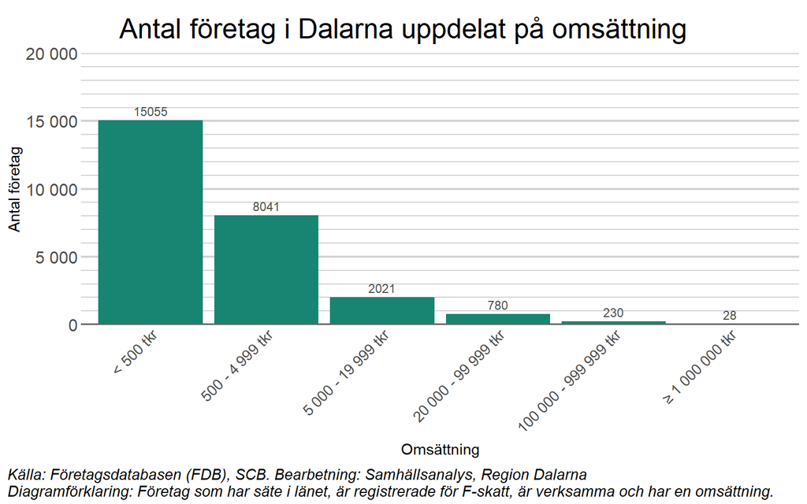

Vilket datum gäller för uttag ur FDB?

Verksamheter inom offentlig sektor är exkluderade, även om de har betydelse för företag i privat sektor i form av kunder. Således kan förändringar inom offentligt sektor få effekt på utvecklingen för företag i privat sektor.

Var tydlig med när den offentliga sektorn är inkluderad eller inte. När behövs den för att sätta proportioner mot det privata?

Arbetsställen behöver också hanteras i någon form eftersom stora företag som är en del av Dalarnas näringsliv har sina säten i andra län. Då behöver arbetsställen som finns i länet och bidrar komma med i analysen.

Ge en kort sammanfattning inledningsvis i respektive avsnitt?

Vilka är betydande för Dalarnas ekonomi - nu och historiskt? Hur konkurrenskraftiga är företag och branscher i ett nationellt perspektiv? Hur ser branschstrukturen ut - mix av stora och små, lönsamma företag? Koppling mot internationella marknader, kunskapsintensitet och förnyelseförmåga?

# 1 Dalarnas näringsliv och företagande

Det här avsnittet ger några övergripande basfakta om Dalarnas näringsliv och företag.

År 2024 hade Malung-Sälen den högsta andelen företagare bland de sysselsatta i Dalarnas kommuner (16,4 procent), medan Ludvika hade den lägsta andelen (6,9 procent). Generellt är andelen företagare högre i de mer glesbefolkade kommunerna i norra Dalarna.

[interactive chart not shown]

Den typiske företagaren är en inrikes född man, medan klart färre utrikes födda kvinnor driver egna företag.

Antal företag i urvalet Antal anställda Omsättning

All data från https://www.foretagsklimat.se/ladda-ner/ (filen statistikfaktorer) går att ladda ned relativt enkelt. Se sårbarhetsanalysen för några exempel

https://www.foretagsklimat.se/dalarnas-lan

Grov branschindelning med omsättning och sysselsättning per bransch 5 största företagen per bransch och deras omsättning och sysselsättning

Från avsnitt 2.2 i kompetensförsörjningsrapporten

Näringslivets struktur har förändrats relativt mycket de senaste dryga 30 åren. I början av 1990 talet var *tillverkning och utvinning* den klart största branschen i Dalarna med mer än 30 000 sysselsatta (se det första diagrammet nedan). Sedan dess har antalet sysselsatta inom branschen minskat med drygt 12 000 personer (se det andra diagrammet nedan).

År 2025 var *hälso- och sjukvård mm* den största branschgruppen, med knappt 28 000 sysselsatta i länet. Detta var något fler än 1990. En bransch där sysselsättningen ökat avsevärt är *företagstjänster, finans mm*, med ungefär 7600 fler sysselsatta år 2025 jämfört med 1990.

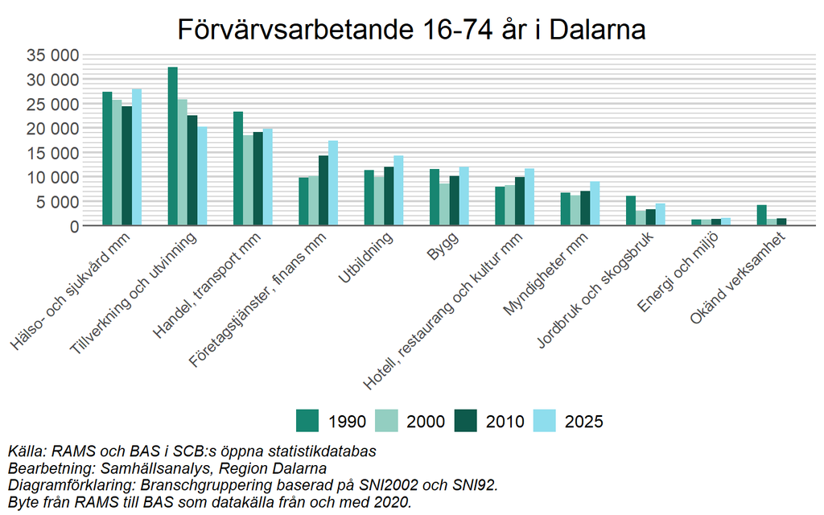

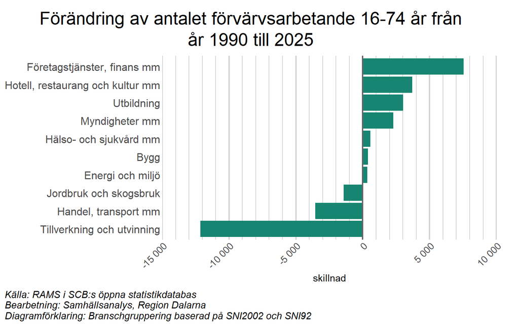

LA- och FA-regioner?

## 1.1 Näringslivets omfattning, utveckling och geografiska fördelning

Ett antal diagram som ger en bild av näringslivets sammansättning i Dalarna.

Dalarnas största privata arbetsgivare är Hitachi Energy Sweden AB i Ludvika som år 2024 hade knappt 3 500 anställda. Länets största offentliga arbetsgivare är Region Dalarna med ungefär 9 400 anställda. I samtliga av Dalarnas kommuner, förutom Ludvika, återfinns den största arbetsgivaren inom offentlig verksamhet och det är i majoriteten av fallen just den kommunala verksamheten som är störst. Falu kommun är undantaget där den största arbetsgivaren är Region Dalarna, vilket är en följd av att Falu lasarett, länets största sjukhus, är placerat i kommunen.

Största arbetsgivare i Dalarna 2024

| Kommun | Arbetsgivare (privat) | Antal anställda | Arbetsgivare (offentlig) | Antal anställda |
| --- | --- | --- | --- | --- |
| Avesta | OUTOKUMPU STAINLESS AB | 825 | Avesta Kommun | 2125 |
| Borlänge | SSAB EMEA AB | 1725 | Borlänge Kommun | 5875 |
| Dalarna | Hitachi Energy Sweden AB | 3475 | Region Dalarna | 9425 |
| Falun | Libra Assistans AB | 625 | Region Dalarna | 5075 |
| Gagnef | Shamsen omsorg AB | 325 | Gagnefs Kommun | 1475 |
| Hedemora | Boliden Mineral AB | 525 | Hedemora Kommun | 1425 |
| Leksand | CLAS OHLSON AKTIEBOLAG | 675 | Leksands Kommun | 1775 |
| Ludvika | Hitachi Energy Sweden AB | 3425 | Ludvika Kommun | 2825 |
| Malung-Sälen | SkiStar Aktiebolag | 325 | Malung-Sälens Kommun | 1075 |
| Mora | FM Mattsson AB (publ) | 325 | Mora Kommun | 2075 |
| Orsa | Orsa Grönklitt Friluftsanläggning AB | 75 | Orsa Kommun | 625 |
| Rättvik | Rättvik Event AB | 275 | Rättviks Kommun | 1325 |
| Smedjebacken | Ovako Bar Aktiebolag | 375 | Smedjebackens Kommun | 975 |
| Säter | Gustafs Scandinavia Aktiebolag | 75 | Säters Kommun | 1225 |
| Vansbro | Lyko Operations AB | 375 | Vansbro Kommun | 925 |
| Älvdalen | STIFTELSEN IDRE FJÄLL | 225 | Älvdalens Kommun | 775 |

Källa: www.foretagsklimat.se, bearbetning: Samhällsanalys, Region Dalarna Notera att flera arbetsgivare kan ha lika många antal anställda, men bara ett syns i tabellen.

Antal företag

Den vanligaste branschen bland Dalarnas företag var år 2023 företagstjänster, med drygt 4 900 aktiva företag. Här ingår exempelvis företag som sysslar med konsultverksamhet eller städ, tjänster som tidigare ofta sköttes internt inom företag, men idag outsourcas i större utsräckning. Detta kan vara en av orsakerna till att antalet anställda inom tillverkning och utvinning har minskat påtagligt sedan 1990-talet (se föregående avsnitt). I Dalarna finns även många företag som sysslar med byggverksamhet av olika slag.

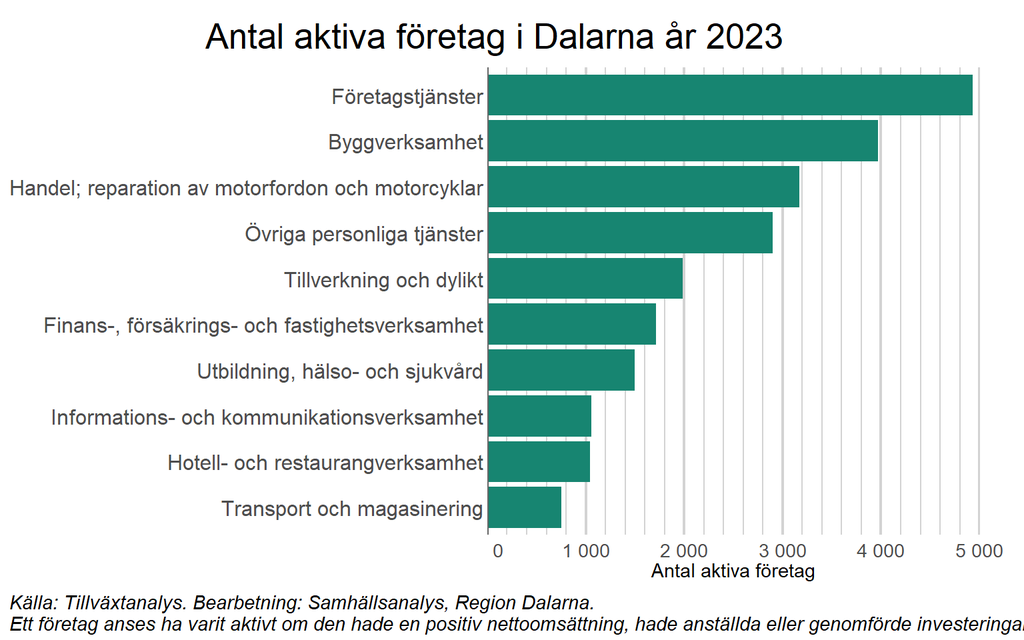

Antal nyetablerade företag

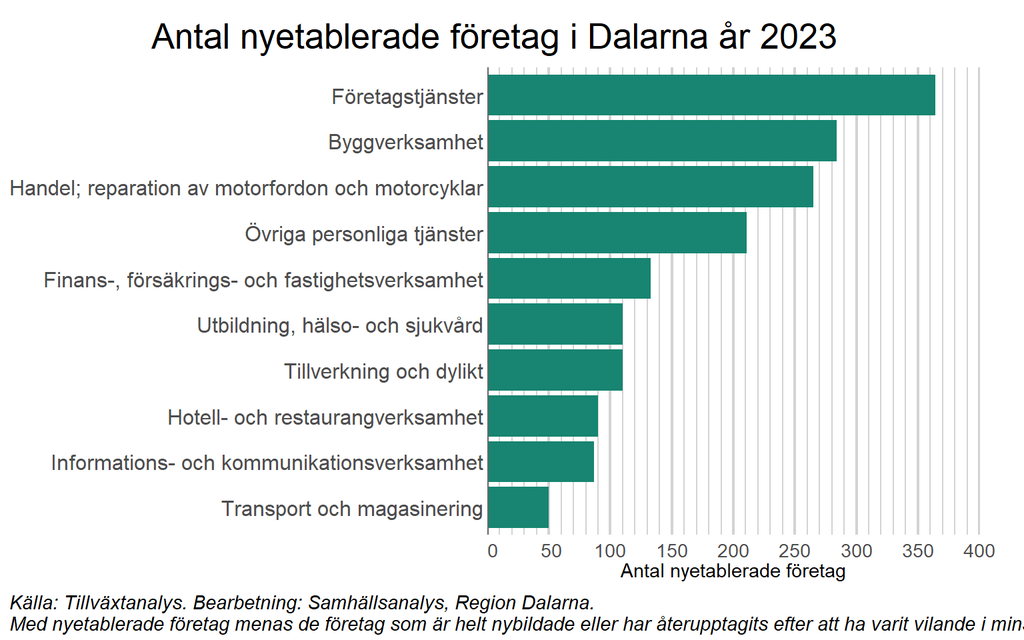

Antal nedlagda företag

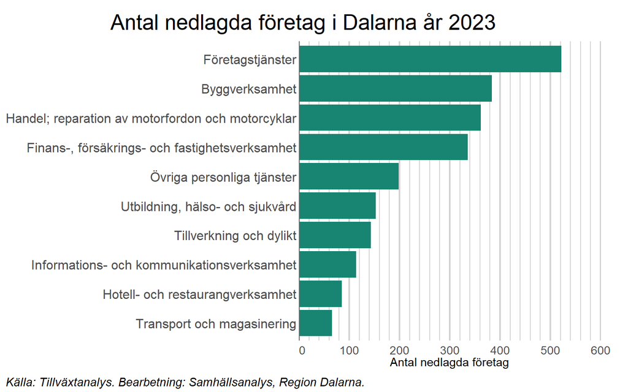

Alternativ med alla tre i samma diagram (bra överblick, men det blir lite i minsta laget med texten)

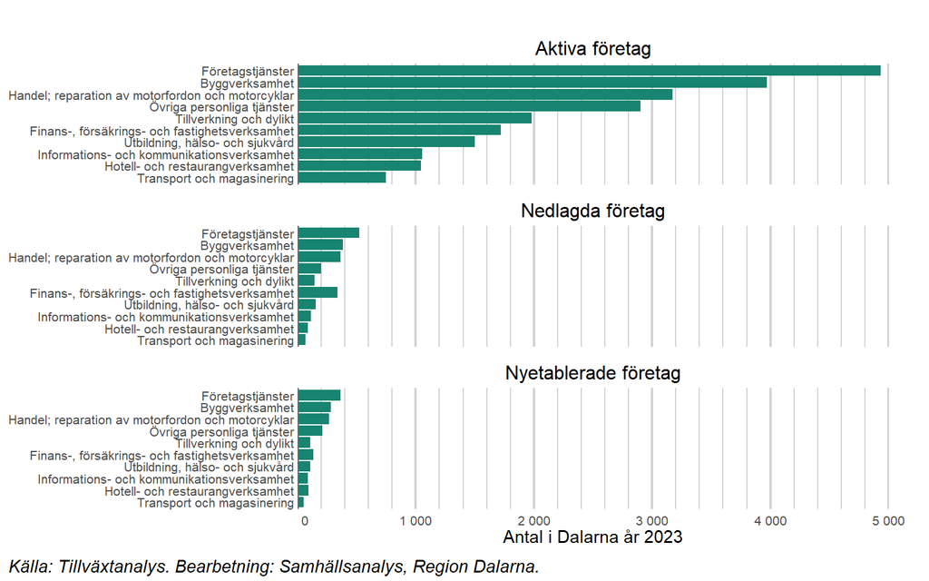

Uppdelat på storleksklass istället

Aktiva företag

Om man istället delar upp antalet företag i olika storleksklasser blir det tydligt att de allra flesta företag är små. Av länets ungefär 23 000 företag har en majoritet (drygt 15 000) inga anställda. Bara ungefär 1 000 företag har 10 eller fler anställda.

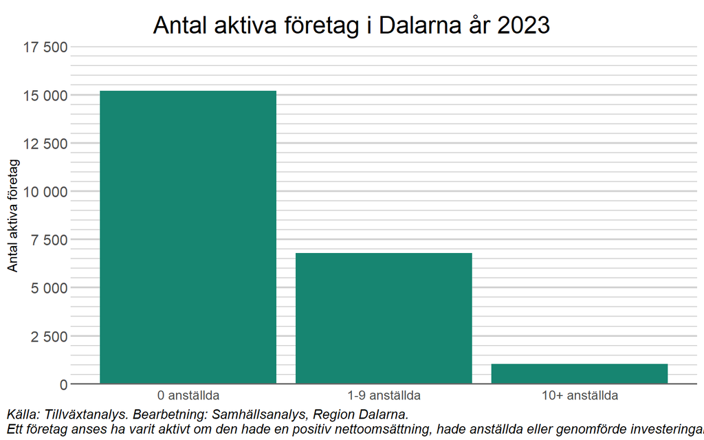

## 1.2 Branscher - omsättning och sysselsatta

Oklart om det finns ett diagramskript för det?

Bubbeldiagrammet?

Blekinge använder samma indelning som Region Skåne, vilket är 40 olika branscher utifrån SNI-indelning. Små branscher exkluderas (<50 anställda). Exkluderar även vissa företag som har stora kapitalrörelser mellan åren, fastighet, finans, försäkring Justering av löpande till fasta priser?

Hur ser vår branschindelning ut? Har vi genomgående samma företagsurval och bara fokus på de privata företagen?

Bara fokus på de privata företagen, men kan vara mindre skillnader mellan SCB och Tillväxtanalys. För längre tidsserier (sysselsatta sedan 1990) har SNI-koderna ändrats, så det är inte samma

Högst nettoomsättning bland de branscherna i Dalarna hade år 2024 tillverkning och utvinning, med en omsättning på drygt 87 miljarder kronor. Detta var en ökning på ungefär 12 procent sedan år 2022. Även branschgruppen handel omsätter relativt mycket, ungefär 75 miljarder kronor.

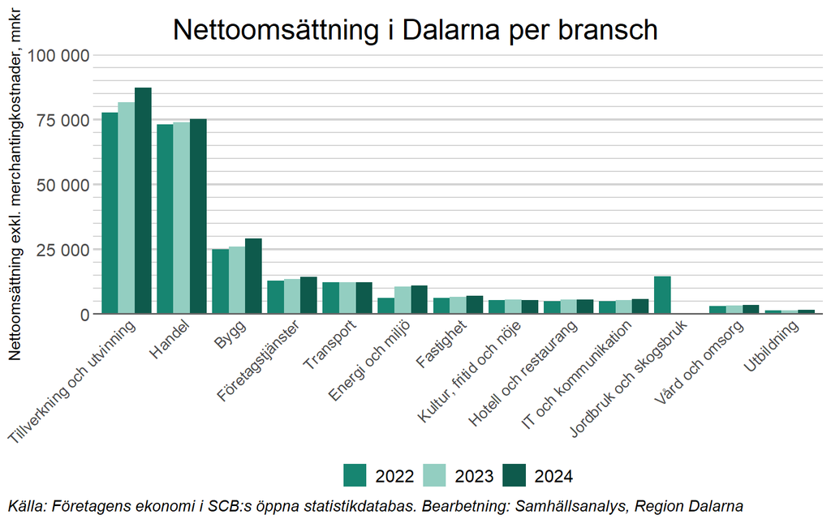

Den bransch som sysselsätter flest personer är tillverkning och utvinning, med ungefär 19 000 anställda år 2024.

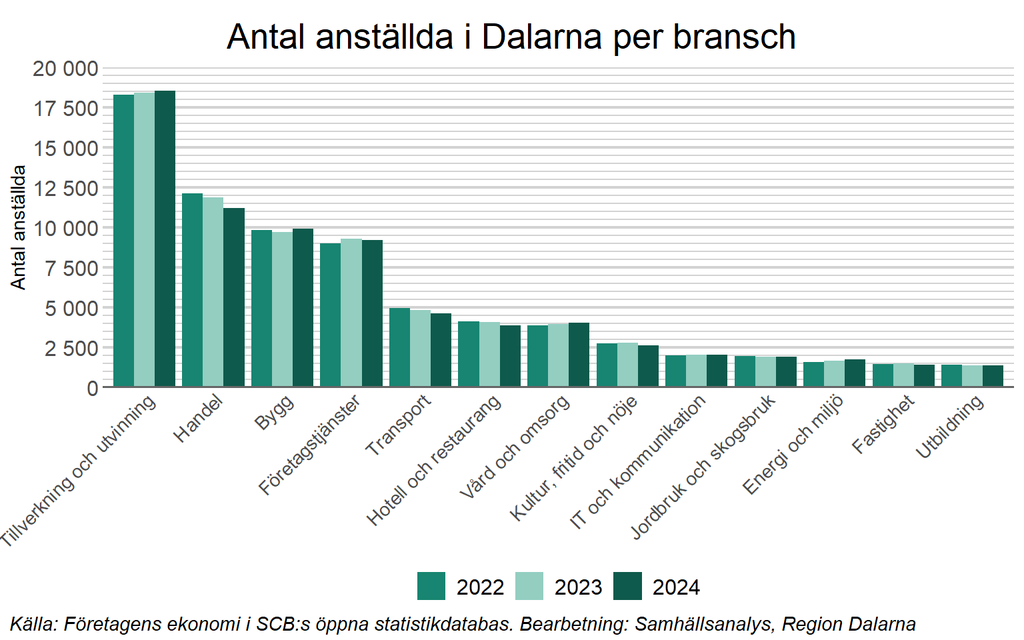

## 1.3 Kommunala variationer

Här kommenterar vi hur det ser ut i våra kommuner, vilka skillnader som finns m m.

Skapa kommunflikar med motsvarande indelning som är klickbara 3 största företagen per bransch och deras omsättning och sysselsättning?

Är det värt att ta det här i ett första steg eller något att komplettera med?

# 2 Regionalräkenskaper (BRP)

Titta tillbaka på utvecklingen för BRP i länet, jämfört med riket och i ett EU-perspektiv.

Hur förhåller sig dessa siffror till det privata respektive det offentliga?

Finns exempelvis: https://www.statistikdatabasen.scb.se/pxweb/sv/ssd/START__NR__NR0105__NR0105A/NR0105ENS2010T03A/

Mer aktuella delar får flyttas in i “Det samhällsekonomiska läget” och vi hänvisar dit för mer aktuell information.

Finns det behov av att visa på vilket konjunkturläge som råder innan vi visar hur det går i näringslivet? Något från SCB:s konjunkturklocka som kan nyttjas?

Sammanställning av utvecklingen av tillväxt, förädlingsvärden, produktivitet, lönesummor per bransch och skattekraft.

Ekonomins utveckling (tillväxt) i ett land mäts normalt via bruttonationalprodukten (BNP). Utgångspunkten är måttet förädlingsvärde, som är värdet av ett företags produktion minus värdet av insatsvarorna i produktionen. Förädlingsvärdet utgör ett företags bidrag till landets BNP och summan av alla förädlingsvärden vid samtliga arbetsställen utgör landets BNP.

På motsvarande sätt är summan av de förädlingsvärden som genereras vid samtliga arbetsställen i en region bruttoregionalprodukten (BRP). Per definition summerar regionernas BRP upp till landets BNP.

Notera dock att förädlingsvärdet i SCB:s databas *Företagens ekonomi* (som används i denna rapport) motsvarar endast en del av det totala förädlingsvärdet i ekonomin, eftersom offentlig sektor, finansiella verksamheter och vissa nationalräkenskapsjusteringar saknas.

Bruttoregionalprodukten (BRP) bygger däremot på regionalräkenskapernas helhetsbild och omfattar hela ekonomin, vilket förklarar att summan av förädlingsvärden i Företagens ekonomi understiger BRP.

## 2.1 Tillväxt

Den ekonomiska tillväxten mäts som förändringen i BNP (eller BRP) mellan två tidsperioder. Det ekonomiska välståndet definieras som nivån på BNP vid en viss tidpunkt och vanligtvis mätt per invånare.

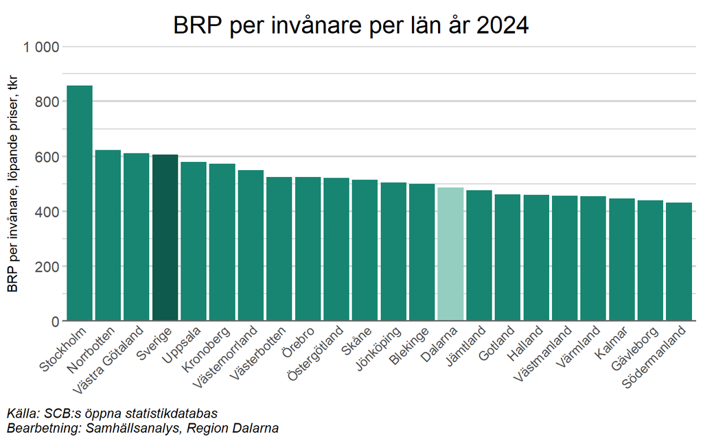

Utvecklingen av BRP per invånare i Dalarna sedan 2000 följer i princip den utveckling som varit för riket som helhet. Noterbart är dock att det under senare år varit en del skillnader mellan de preliminära och slutliga BRP-siffrorna i SCB:s redovisningar. De preliminära siffrorna bör därför bedömas med försiktighet.

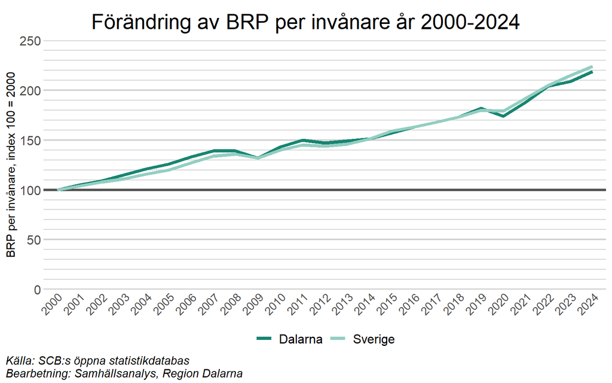

## 2.2 Förädlingsvärden

Ett företags förädlingsvärde är det värde som skapas i verksamheten, eller enklare uttryckt det värde som företaget självt skapar. Förädlingsvärdet mäts vanligen som värdet av företagets produktion minus värdet av insatsvarorna i produktionen och utgör ett företags bidrag till landets BNP. Summan av alla förädlingsvärden vid samtliga arbetsställen utgör landets BNP. På motsvarande sätt är summan av de förädlingsvärden som genereras vid samtliga arbetsställen i en region bruttoregional produkten (BRP). Per definition summerar regionernas BRP upp till landets BNP.

Högst förädlingsvärde bland branscherna i Dalarna hade år 2024 tillverkning och utvinning, med ett förädlingsvärde på drygt 19 miljarder kronor. Detta var dock en minskning på ungefär 9 procent sedan år 2022. Även branschgrupper som handel, bygg och företagstjänster har relativt höga förädlingsvärden.

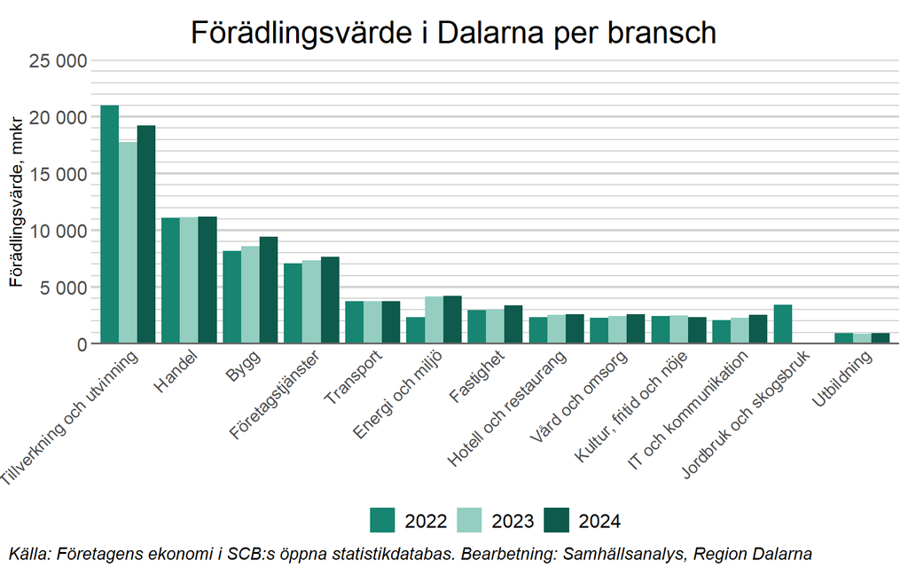

Kan vi kika på lite längre sikt och eventuellt göra jämförelser med riket alternativt inom NMS? Det känns som att det blir lite för ryckigt när vi tittar på förädlingsvärdet under så kort tid.

Tveksamt med längre sikt då det är olika tabeller med delvis olika branscher som sannolikt är svåra att jämföra. Jämförelser med riket/NMS är kanske mer intressanta för BRP (se nedan)/

Har vi ett totalt förädlingsvärde, både utifrån BRP-beräkningen och utifrån FEK-beräkningen för att se skillnaden mellan det offentliga och det privata samt att kunna ställa branschernas andel i relation till det totala värdet? Se kommentar ovan om BRP uppdelat på sektor. Under rubriken regionalräkenskaper i statistikdatabasen finns lite olika tabeller över BRP/

## 2.3 Produktivitet

För att mäta produktivitet används arbetsproduktiviteten som definieras som förädlingsvärdet per arbetsinsats (vanligen antal arbetade timmar). Enklare uttryckt visar arbetsproduktiviteten hur mycket värde som skapas per arbetad timma. På regional nivå finns inte arbetade timmar tillgängligt, vilket innebär att produktiviteten mäts genom förädlingsvärdet dividerat med antal sysselsatta.

Finns det någon förklaring i att vi skulle ha fler sysselsatta som arbetar färre timmar än övriga län? Kan man söka den informationen bakvägen på något sätt? Alternativt är de som är sysselsatta i genomsnitt inte särskilt effektiva i det de gör.

Arbetsproduktiviteten per bransch? Nej, inte så vitt jag kan se. Finns under Nationalräkenskaper/Regionalräkenskaper/Regionalräkenskaper årsdata i statistikdatabasen

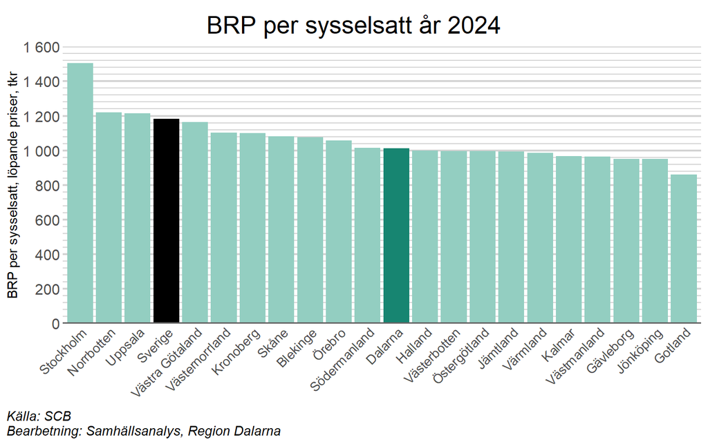

Utvecklingen av arbetsproduktiviteten förefaller vara svag över en längre tid, vilket visar sig i att gapet mellan riksgenomsnittet och Dalarna ökar successivt. Nedgången i samband med pandemin, vilken påverkade besöksnäringen i länet, har dröjt sig kvar under de efterföljande åren.

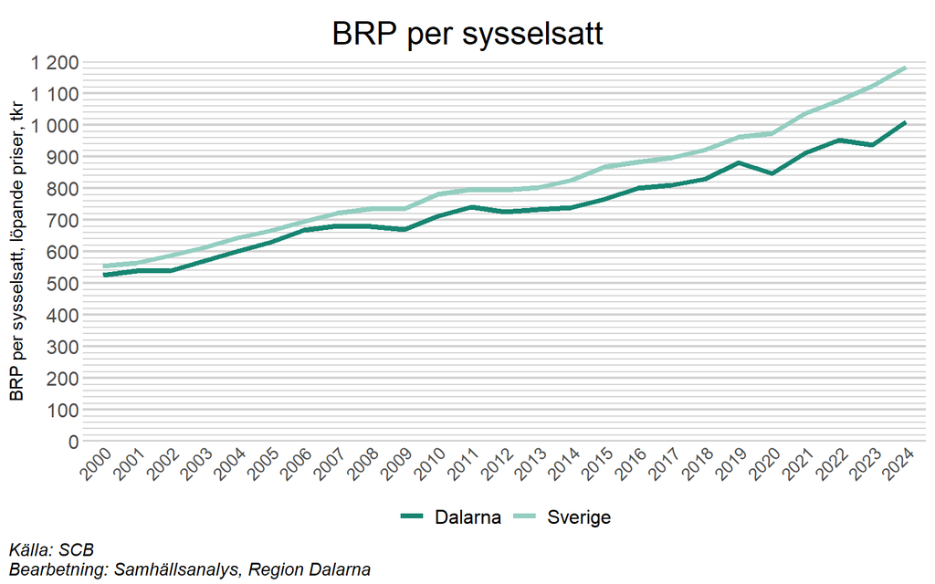

Förädlingsvärden förklaras och redovisas per bransch om möjligt.

## 2.4 Lönesummor

Vad kan vi göra här?

## 2.5 Skattekraft

Skattekraften speglar kommuninvånarnas inkomster och ger en förutsättning för den kommunala välfärden.

Den högsta skattekraften vid ingången av 2025 per invånare finns i Falun, Leksand och Smedjebackens kommun, medan Älvdalen, Orsa och Vansbro har den lägsta skattekraften bland länets kommuner. Vansbros skattekraft 2025 var knappt 85 procent av nivån i Falun.

Skattekraften i Dalarnas kommuner har ökat i genomsnitt med 168 procent mellan 1995 och 2025. Den starkaste utvecklingen har Säters kommun med knappt 182 procents ökning över de trettio åren. Svagast utveckling finns i Borlänge med 151 procent.

Under de senaste 10 åren har Malung-Sälen haft den starkaste utvecklingen med 40 procent, medan Avesta har haft den svagaste med drygt 27 procent.

# 3 Företagens lönsamhet

Här tittar vi på lönsamhetsmått, hur nyföretagandet utvecklas och hur företagens överlevnadsgrad ser ut på kort och lång sikt.

## 3.1 Lönsamhetsmått

Earnings Before Interest and Taxes (EBIT), Return on Assets (ROA) och Return on Equtiy (ROE).

## 3.2 Nyföretagande och Överlevnadsgrad

Hur är situationen när det gäller tillkomsten av nya företag och hur ser överlevnadsgraden ut över tid? Startas det många bolag som sedan inte finns kvar efter några år?

Karta över nyföretagande per 1000 invånare per kommun

[interactive chart not shown]

# 4 Shift-share eller specialisering?

Är det här något vi borde inkludera? En vanlig metod för att analysera utvecklingen är att använda sig av en så kallad shift-share analys. Metoden är ett verktyg för att identifiera dels inom vilka branscher länet växer, dels hur väl länet har presterat i relation till riket. Givet utvecklingen av svensk ekonomi och konjunkturen i branscher kan vi identifiera ett förväntade utfall som relateras till det faktiska utfallet i sysselsättning.

Analysen kvantifierar således den regionala prestationen och gör det möjligt att identifiera branscher med en särskilt god utveckling i länet och som inte kan förklaras av den svenska ekonomins utveckling i stort eller av branschens konjunkturutveckling oavsett om det är växande eller krympande bransch. I de branscherna antas länet ha särskilda fördelar och stark konkurrenskraft. Analysen syftar således till att besvara hur stor del av utvecklingen i en bransch som kan förklaras av regionala faktorer.

En LA-regions allmänna specialisering mäts genom att studera regionens avvikelse från Sveriges genomsnitt. Måttet beräknas enligt följande ekvation: (1⁄2) ∑|𝑆𝑗𝑟 − 𝑆𝑗|100

𝑆𝑗𝑟 = andelen sysselsatta i bransch j i LA-region r 𝑆𝑗 = andelen sysselsatta i bransch j i Sverige som helhet |𝑆𝑗𝑟 − 𝑆𝑗| = det positiva värdet av skillnaden mellan andelen sysselsatta i bransch j i region r och andelen sysselsatta i bransch j i hela landet

# 5 Internationella relationer

Här tittar vi på näringslivet i Dalarnas export- och importvolymer. Något att hämta från det pågående arbetet med export- och importsammanställning?

## 5.1 Export och import

Dalarna hade under 2024 en positiv handelsbalans, d v s värdet av exporten översteg värdet av importen. Under de senaste 25 åren har handelsbalansen varit positiv och successivt ökat från 12 miljarder kronor 1999 till närmare 26 miljarder år 2024.

Exportvärdet år 2024 var drygt 50 miljarder kronor och importvärdet år 2024 var cirka 25 miljarder, d v s exporten är mer än dubbelt så stor som importen.

34 företag i länet exporterade under 2024 för mer än 100 miljoner kronor. Det exakta exportvärdet per företag går finns inte i företagsstatistiken, men de två största exportörerna utifrån omsättningsklass är Outokumpu Stainless AB och Stora Enso AB med mer än tio miljarder kronor. Även Clas Ohlson AB är en stor exportör och det högexporterande företag som har flest anställda.

*Kan vi ta fram mer exakta exportsiffror än de som finns i shinyappen?*

Det är 13 företag som både exporterar och importerar för mer än 100 miljoner kronor under 2024. Samtliga omsätter minst 1 miljard kronor för verksamhetsåret, utom Autoform i Malung AB och Dellner Couplers AB.

*Kan vi ta fram mer exakta importsiffror än de som finns i shinyappen?*

## 5.2 Utländskt ägande

Antal anställda - bransch

Tillverkning och utvinning är den bransch i Dalarna där klart flest antal anställda jobbar i företag som ägs från utlandet (ungefär 8 200 personer år 2024).

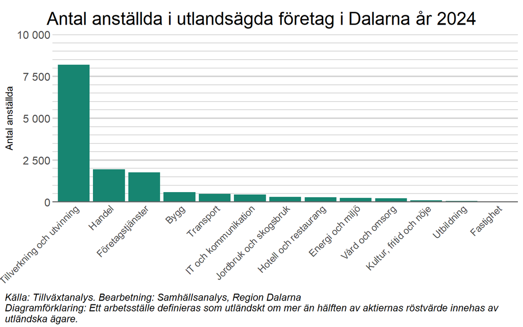

Antal anställda - ägarland

Flest antal anställda i utlandsägda företag jobbar i företag som ägs i Japan (ungefär 4 400 personer). Detta hänger samman med att Hitachi Energy, Dalarnas största privata arbetsgivare med över 3 000 anställda, är ett japanskt företag. Många jobbar även i företag som ägs i grannländer som Finland och Norge.

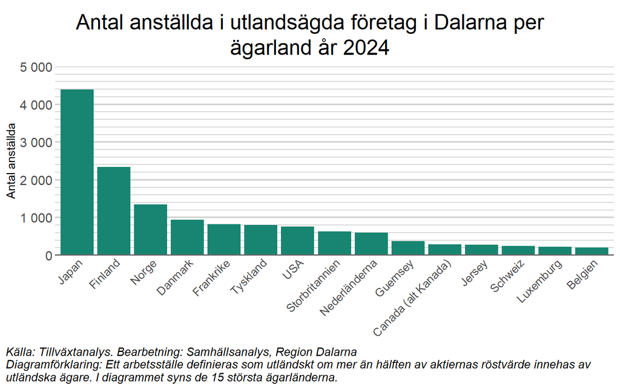

Antal arbetsställen - bransch

Flest utlandsägda arbetsställen i Dalarna återfinns istället inom handel, med ungefär 280 arbetsställen år 2024.

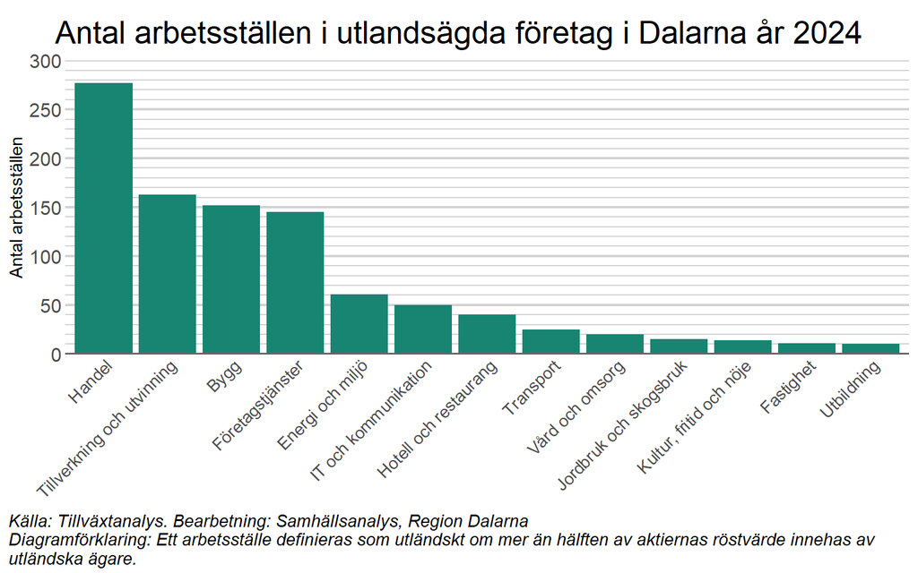

Antal arbetsställen - ägarland

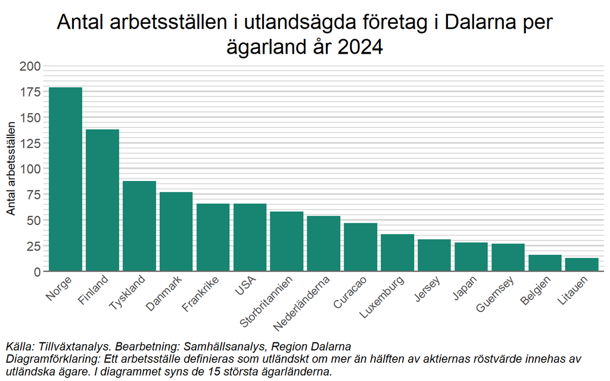

# 6 Arbetskraften

Hänvisa till en uppdaterad kompetensförsörjningsrapport/Shiny-appar?

Vad är viktigt för näringslivsperspektivet? Vilka är det som är sysselsatta? På branschnivå? Vilken utbildning har de? Hur väl matchade är de i sina yrken? Pendlar de till arbetet?

Vilken potential finns det för näringslivet att utvecklas utifrån arbetskraftens sammansättning?

# 7 Det lokala företagandet

Vad kan vi säga om hur företag ägs och sysselsätter sin verksamhet lokalt? Hur beroende är Dalarnas företag av marknader utanför länet och utanför riket?

Utlandsägda företag/arbetsställen (hanteras under internationella relationer, men kan även vara en dimension i en lokal genomgång)

# 8 Det sociala företagandet

Finns det något vi kan göra för att beskriva den sociala dimensionen i länets företagande?

# 9 Det hållbara företagandet

Energiförbrukning Minskade CO2-utsläpp Grön omställning m m

# 10 Avslutande diskussion

Vad kan vi säga om denna genomgång?